# Minicurso Octave/Matlab

Prof. MsC. Carlos de Castro

Bem vindos ao minicurso de Octave/Matlab.

## Sumário

Conhecendo o programa  
Principais janelas  
Operações básicas  
Matrizes e Vetores  
Operações com Matrizes e Vetores  
Strings  
Algumas funções especiais  
Sistema linear  
Plotando gráficos  
Cálculo  
Instalação  
Limite  
Derivada  
Integral  
Gráficos das funções simbólicas  
Programação  
Algoritmo  
Comando lógico-relacionais  
Laço FOR  
Laço WHILE  
If, Elseif e Else  
Switch, case, otherwise  
Funções

## Conhecendo o programa

GNU Octave é uma linguagem de alto nível, construída inicialmente para computação numérica. Ela provê uma interface de linha de comando para resolver problemas lineares e não lineares numericamente e executa outros experimentos numéricos que são compatíveis com MATLAB.

A imagem a seguir é a interface do MATLAB e OCTAVE.

[figure not shown]

## Instalação

Acessar [Site](https://www.gnu.org/software/octave/download]) (lá tem tudo o que precisa saber, para todos os sistemas operacionais).

## Principais janelas

### Gerenciador de arquivos

[figure not shown]

É o local onde estarão os scripts e funções que você irá desenvolver para o Octave. Você pode alterar a localização da pasta, navegando no gerenciador.

### Janela de Comandos

[figure not shown]

É o local onde onde podemos escrever e executar os programas, funções e fórmulas matemáticas.

### Editor

[figure not shown]

No editor é onde você escreve seus scripts e funções, e salva-os na pasta. Esse arquivo salvo terá extensão *.m* e aparecerá no gerenciador de arquivos (caso você salve lá). Você poderá executar suas funções chamando-as pelo nome na Janela de comandos ou clicando com o botão direito no arquivo, em gerenciador de arquivos, e clicar em *Executar*.

|  | Para criar um script novo, clique no botão que fica no canto superior esquerdo, com o nome de *Novo script* |
| --- | --- |

### Ambiente de Trabalho

[figure not shown]

Essa janela irá aparecer todas as variáveis que estão ativas. Nele você pode ver o nome da variável, a classe (se é char - caractere, double - ponto flutuante real com dupla precisão, int - inteiro, etc), a dimensão ($1\times 3$ - vetor 'deitadinho' de 1 linha e 3 colunas) e o valor.

### Histórico de comandos

[figure not shown]

Nesse ambiente, você poderá ver o histórico de comandos feitos, desde o momento da primeira abertura do programa.

### Janela de troca de ambiente

[figure not shown]

Essa janelinha fica logo abaixo do editor ou da Janela de Comandos. Nela, você consegue trocar entre esses ambientes.

Aqui no Notebook, tanto os scripts, quanto a janela de comando são representadas na mesma célula, como a que vemos abaixo:

```matlab
x = 3;
sqrt(3)

for i=1:5
    x = x**i
end
```

```
ans =  1.7321
x =  3
x =  9
x =  729
x =    2.8243e+11
x =    1.7970e+57
```

Na janela do octave:

[figure not shown]

Aqui no Jupyter, posso fazer tudo em uma mesma célula:

```matlab
3+2
x=3;
y=2;
x+y
x+10
10+y
x=3+2;
x
```

```
ans =  5
ans =  5
ans =  13
ans =  12
x =  5
```

Ou podemos fazer separadamente, pra ficar igual à janela de comando.

```matlab
3+2
```

```
ans =  5
```

```matlab
x=3;
```

```matlab
y=2;
```

```matlab
x+y
```

```
ans =  5
```

```matlab
x+10
```

```
ans =  13
```

```matlab
10+y
```

```
ans =  12
```

```matlab
x=3+2;
```

```matlab
x
```

```
x =  5
```

Como as células aqui do Jupyter são a mistura do editor de funções com a janela de comando, vamos utilizar apenas uma célula, quando conveniente, a partir de agora. :)

Caso queira rodar o kernel do Octave no Jupyter Notebook, acesse o git: https://github.com/Calysto/octave_kernel e veja como instalar no seu computador. Caso ainda não tenha jupyter, instala o Anaconda por aqui https://anaconda.org/anaconda/jupyter e volta lá no Git do Octave_kernel para instalar.

Perceberam uma coisa interessante? O caractere `;` faz com que você controle o que aparece ou o que não aparece na janela de comando. Vamos fazer um teste.

Na célula a seguir, vou fazer uma soma em looping, ou seja, vou pedir pro octave fazer uma soma de números naturais, de 1 até um *n* determinado. Para isso, usarei um `loop for`, que veremos mais pra frente.

```matlab
% Aqui eu vou esquecer o ;. O que vai acontecer?
n=15
soma = 0
for i = 1:n
    soma = soma + i
end

print = ['A soma de 1 até ' int2str(n) ' é ' int2str(soma) '.']
disp(print)
```

```
n =  15
soma = 0
soma =  1
soma =  3
soma =  6
soma =  10
soma =  15
soma =  21
soma =  28
soma =  36
soma =  45
soma =  55
soma =  66
soma =  78
soma =  91
soma =  105
soma =  120
print = A soma de 1 até 15 é 120.
A soma de 1 até 15 é 120.
```

Apareceu um monte de coisa que eu não queria. Como fazer para não aparecer?

[figure not shown]

```matlab
n=100;
soma = 0;
for i = 1:n
    soma = soma + i;
end

print = ['A soma de 1 até ' int2str(n) ' é ' int2str(soma) '.'];
disp(print)
```

```
A soma de 1 até 100 é 5050.
```

## Operações básicas

| Operação | Símbolo | Exemplo |
| --- | --- | --- |
| Adição | $+$ | $3$ $+$ $2$ $=$ $5$ |
| Subtração | $-$ | $3$ $-$ $2$ $=$ $1$ |
| Multiplicação | $\ast$ | $3$ $\ast$ $2$ $=$ $6$ |
| Divisão usual | $/$ | $3$ $/$ $2$ $=$ $1.5$ |
| Divisão ivertida* | $\setminus$ | $3$ $\setminus$ $2$ $=$ $0.\overline{6}$ |
| Potênciação | ^ ou $\ast\ast$ | $3$ ^ $2$ $=$ $9$ |
| Módulo (ou resto sob divisão Euclidiana) | mod( $a$,$b$) | mod($3$ ,$2$) $=$ $1$ |

*`jajá veremos para que isso serve.`

## Formato de número em ponto flutuante

Ao trabalhar com ponto flutuante (double ou float), é possível obter diversas visualizações desses números com o Octave. A seguir, vemos uma lista de alguns formatos possíveis:

| Sintaxe | formato | Exemplo($\pi$) |
| --- | --- | --- |
| format short | precisão simples | 3.1416 |
| format long | precisão dupla | 3.14159265358979 |
| format short $e$ | precisão simples $e$ | 3.1416e+00 |
| format long $e$ | precisão dupla $e$ | 3.14159265358979e+00 |
| format hex | Hexadecimal | 400921fb54442d18 |
| format bank | 2 casas decimais | 3.14 |

| Sintaxe | formato | Exemplo($\approx \pi$) |
| --- | --- | --- |
| format rat | Quociente | $355/113$ |
| **Erro relativo** |  | 8.4914$\times 10^{-8}$ |

## Alguns comandos interessantes

- **help**: Ao digitar `>> help <function>` na janela de comando do octave/matlab, aparecerá na mesma janela os detalhes acerca da função procurada.

#### Exemplo

```matlab
help sin
```

```
'sin' is a built-in function from the file libinterp/corefcn/mappers.cc

 -- sin (X)
     Compute the sine for each element of X in radians.

     See also: asin, sind, sinh.

Additional help for built-in functions and operators is
available in the online version of the manual.  Use the command
'doc <topic>' to search the manual index.

Help and information about Octave is also available on the WWW
at http://www.octave.org and via the help@octave.org
mailing list.
```

- **lookfor**: O comando lookfor procura por um determinado texto na biblioteca do Octave/MatLab.

#### Exemplo

```matlab
lookfor eigenvalue
```

```
eig                 Compute the eigenvalues (LAMBDA) and optionally the right e
                    igenvectors (V) and the left eigenvectors (W) of a matrix o
                    or a pair of matrices.
ordschur            Reorders the real Schur factorization (U,S) obtained with t
                    he 'schur' function, so that selected eigenvalues appear in
                    n the upper left diagonal blocks of the quasi triangular Sc
                    chur matrix.
qz                  QZ decomposition of the generalized eigenvalue problem
condeig             Compute condition numbers of a matrix with respect to eigen
                    values.
polyeig             Solve the polynomial eigenvalue problem of degree L.
eigs                Calculate a limited number of eigenvalues and eigenvectors
                    of A, based on a selection criteria.
```

## - **Clc** e **Clear**: O comando `Clc` e `Clear` apagam as informações da Janela de comando e da lista de variáveis no "Ambiente de trabalho", respectivamente.

- **Who**: lista todas as variáveis do "Ambiente de trabalho";
- **Quit**: Sai do Octave/Matlab

### Outros comandos

| comando | resulta em |
| --- | --- |
| pi | $\pi$ |
| $i$ ou $j$ | se não foi usado como outra variável, $i$ $=$ $j$ $=$ $\sqrt{-1}$ |
| eps | Menor número tal que $1+eps>1$. Aqui na minha máquina: $eps=2.2204e-16$ |
| realmin | Menor representação em ponto flutuante: $realmin=2^{-1022}$ |
| realmax | Maior representação em ponto flutuante: $realmax=2^{1024}$ |
| inf | Infinito |
| NaN | Not-a-number. Por ex.: $\frac{0}{0}$ |

## Matrizes e vetores

A construção de matrizes e vetores no Octave já está inclusa na instalação padrão do programa. Na sintaxe, o vetor é representado como um conjunto de números, separados em linhas e colunas, organizados entre `[]`, de modo que:

- A separação por espaço `` ` ou vírgula ``,` representa números em uma mesma linha da matriz;
- A separação por `;`, nesse caso, representa números em diferentes linhas.

### Exemplo

1) Para construir um vetor linha $x$, basta criar a lista com seus elementos separados por `,` ou por espaço :

```matlab
x=[1 2 3 4]
x=[1,2,3,4]
```

```
x =

   1   2   3   4

x =

   1   2   3   4
```

### Exemplo

2) Para construir um vetor coluna $y$, basta criar a lista com seus elementos separados por `;`: (não se preocupe, o ponto e vírgula no final do vetor continua existindo).

```matlab
y=[1;2;3;4]
z=[1;3;2;4];
```

```
y =

   1
   2
   3
   4
```

### Exemplo

```matlab
M = [1 2 3;4,5,6;7,8 9]
%Para deixar mais bonito, sugiro sempre fazer da seguinte forma
M = [1 2 3;
     4 5 6;
     7 8 9];
```

```
M =

   1   2   3
   4   5   6
   7   8   9
```

**Obs**: O Octave/Matlab aceita variáveis como entrada das matrizes.

### Exemplo

```matlab
format bank
k=10;
x=sqrt(3)^5;
M = [k k^2 sqrt(k);
     x sqrt(x) x/k;
     pi 2*pi sin(pi)]
```

```
M =

    10.00   100.00     3.16
    15.59     3.95     1.56
     3.14     6.28     0.00
```

### Vetores linearmente espaçados

Na Álgebra Linear, Processamento de Sinais, Análise Numérica, etc, é comum utilizar de vetores com uma padronização entre os seus elementos. Essa padronização pode ser obtida de algumas maneiras, especialmente

- vetores linearmente espaçados, isto é, a se $x=[x_1, x_2, \cdots, x_k]^T$, então $x_i-x_{i-1}=r, r\in \mathbb{R}$ e $\forall i \in [1,k].$

A sintaxe para criar esses vetores é simples: Se quisermos um vetor $x$, indo de $n\in\mathbb{R}$ até no máximo $m\in\mathbb{R}$, com a distância entre seus elementos $q\in\mathbb{R}$, basta fazermos $$x=[n:q:m].$$

#### Exemplo

```matlab
format short
n=0.2
m=0.5
q=1/sqrt(1127.5)
x1=[n:q:m]
```

```
n =  0.20000
m =  0.50000
q =  0.029781
x1 =

 Columns 1 through 8:

   0.20000   0.22978   0.25956   0.28934   0.31912   0.34891   0.37869   0.40847

 Columns 9 through 11:

   0.43825   0.46803   0.49781
```

- Vetores linearmente espaçados, determinado o número de elementos do vetor.

Aqui, usaremos a função `>>linspace(n, m, N)`, em que $n\in\mathbb{R}$ é o primeiro elemento do vetor, $m\in\mathbb{R}$ é o último elemento do vetor e $N\in \mathbb{N}$ é o número de elementos do vetor.

#### Exemplo

```matlab
n=0.2
m=0.5
N=11
x2=linspace(n,m,N)
```

```
n =  0.20000
m =  0.50000
N =  11
x2 =

 Columns 1 through 8:

   0.20000   0.23000   0.26000   0.29000   0.32000   0.35000   0.38000   0.41000

 Columns 9 through 11:

   0.44000   0.47000   0.50000
```

**OBS**: Veja que os dois métodos construíram vetores diferentes, com o mesmo número de elementos e determinados o mesmo $n$ e $m$.

```matlab
format short
erro=norm(x1-x2)
ERRO=x1-x2
```

```
erro =  0.0042938
ERRO =

 Columns 1 through 6:

   0.0000000  -0.0002188  -0.0004377  -0.0006565  -0.0008753  -0.0010942

 Columns 7 through 11:

  -0.0013130  -0.0015318  -0.0017507  -0.0019695  -0.0021883
```

### Acessando elementos de matrizes e vetores

Dada uma matriz $$A=\left(\begin{array}{ccc} m_{11} & m_{12} & m_{13} \\ m_{21} & m_{22} & m_{23} \\ m_{31} & m_{32} & m_{33} \end{array}\right)$$ como podemos acessar os elementos da matriz? Isto é, caso precisamos obter o elemento que se encontra na linha `3`, coluna `2` da matriz, acessamos a partir do Octave.

As `sintaxes` para acesso dos elementos de matrizes $(M\in\mathbb{C}^{n\times n})$ e vetores $(v\in\mathbb{C}^n)$, para algum $n\in \mathbb{N}$, no Octave/Matlab é $$M/v(\ell,c),$$ em que $\ell,c\in\mathbb{N}$ são os índices da(o) matriz/vetor. No caso de vetores, a sintaxe pode ser tanto $$v(\ell,1)\text{ ou }v(\ell) \text{ (para o caso de vetor coluna)}$$ ou $$v(1,c)\text{ ou }v(c) \text{ (para o caso de vetor linha)}.$$

Para acessar linhas ou colunas inteiras, ou até partes da matriz, é possível utilizar as `sintaxes`:

- $M(:,c)\text{ (para acessar todos os elementos da coluna $c$ - resultando em um vetor coluna com $n$ elementos)}$
- $M(\ell,:)\text{ (para acessar todos os elementos da linha $\ell$ - resultando em um vetor linha com $n$ elementos)}$
- $M(a:b,p:q) \text{(para acessar os elementos que estão entre as linhas $a$ e $b$ as colunas $p$ e $q$ - resultando em uma matriz $M'\in\mathbb{R}^{(b-a)\times (q-p)}$)}$

Voltando à matriz $A$, podemos criar o seguinte esquema:

$$A=\left(\begin{array}{ccc} m_{11} & m_{12} & m_{13} \\ m_{21} & m_{22} & m_{23} \\ m_{31} & m_{32} & m_{33} \end{array}\right)=\left(\begin{array}{ccc} A(1,1) & A(1,2) & A(1,3) \\ A(2,1) & A(2,2) & A(2,3) \\ A(3,1) & A(3,2) & A(3,3) \\ \end{array}\right) = \left(\begin{array}{ccc} \rule{12pt}{.6pt} & A(1,:) & \rule{12pt}{.6pt} \\ \rule{12pt}{.6pt} & A(2,:) & \rule{12pt}{.6pt} \\ \rule{12pt}{.6pt} & A(3,:) & \rule{12pt}{.6pt} \\ \end{array}\right)=\left(\begin{array}{ccc} \rule{.6pt}{12pt} & \rule{.6pt}{12pt} & \rule{.6pt}{12pt} \\ A(:,1) & A(:,2) & A(:,3) \\ \rule{.6pt}{12pt} & \rule{.6pt}{12pt} & \rule{.6pt}{12pt} \\ \end{array}\right).$$

Antes de passarmos para operações entre matrizes e vetores, vamos fazer uns exercícios.

**Obs**: Para excluir uma linha ou coluna de uma matriz, basta fazer $M(:,p) = []$ (para excluir a $p$-ésima coluna da matriz, ou $M(q,:)=[]$ para excluir a $q$-ésima linha.

### Exercícios

1) Escolha $m,n\in \mathbb{N}$, $3 \leq m,n \leq 10$ para criar uma matriz aleatória $M\in\mathbb{R}^{m\times n}$.

```matlab
m = 5; % Mude esse número, se quiser.
n = 5; % Mude esse número, se quiser.
M = rand(m,n); % A função ones é nativa do Octave/Matlab que cria uma matriz em que todos os elementos são iguais a 1
```

2) Altere a primeira coluna e a primeira linha da matriz por um vetor com números aleatórios de $0$ a $1$ (utilize a função $rand()$).

3) Escolha uma submatriz $M'\in \mathbb{R}^{2\times 2}$ da sua matriz $M$ e substitua por uma matriz de identidade $I_{2\times 2}$ (Use a função eye$(\cdot)$).

```matlab
% Faça a parte 2 e 3 aqui
```

4) Altere o elemento da linha $m-2$ e coluna $2$ para o número $NUM=randi(m*n)$ (randi é uma função que devolve um número inteiro aleatório de $0$ a $m\cdot n$).

```matlab
% Faça a parte 4 aqui
```

5) Separe sua matriz $M$ em vetores coluna e vetores linha. (por exemplo, se $$M=\left(\begin{array}{ccc} 1 & 2 & 3 \\ 4 & 5 & 6 \\ 7 & 8 & 9 \end{array}\right),$$ então teremos os vetores coluna $$c1=\left(\begin{array}{c} 1 \\ 4 \\ 7 \end{array}\right),c2=\left(\begin{array}{c} 2 \\ 5 \\ 8 \end{array}\right)\text{ e } c3=\left(\begin{array}{c} 3 \\ 6 \\ 9 \end{array}\right)$$ e os vetores linha $$\ell1=\left(\begin{array}{ccc} 1 & 2 & 3 \end{array}\right),$$ $$\ell2=\left(\begin{array}{ccc} 4 & 5 & 6 \end{array}\right)\text{ e } $$ $$\ell3=\left(\begin{array}{ccc} 7 & 8 & 9 \end{array}\right).\left. \right)$$

```matlab
% Faça a parte 5 aqui
```

### Operações com matrizes e vetores

Para efetuar operações com matrizes e vetores, é preciso ter um pouco de cuidado. Devemos, aqui, lembrar da álgebra linear antes de sair fazendo produto de vetores e matrizes.

Lembrando que em um espaço vetorial $V$ qualquer definido sobre um corpo $\mathbb{K}$, definimos a soma e o produto por escalar entre os elementos desse espaço, isto é, se $v,w \in V$ e $V$ é um espaço vetorial, então $v+w \in V$ e $\lambda v \in V$, qualquer que seja $\lambda \in \mathbb{K}$. Da mesma forma, o Octave/Matlab não vai saber o que fazer se eu pegar $v \in V$ e $w \in W$, com $V$ e $W$ espaços vetoriais tais que $W\cap V = \emptyset$ e fizer $v+w$ ou $w \cdot v$.

Podemos definir, aqui, algumas operações possíveis entre vetores, matrizes e escalares.

Se $v=(v_1 \ v_2 \ \cdots \ v_n)^T$ e $w=(w_1 \ w_2 \ \cdots \ w_n)^T$ e $\lambda \in \mathbb{C}$:

- $v+w= (v_1+w_1 \ v_2+w_2 \ \cdots \ v_n+w_n)^T$ (no octave, utiliza-se $v+w$ para efetuar a soma).
- $\lambda v = (\lambda v_1 \ \lambda v_2 \ \cdots \ \lambda v_n)^T$ (no Octave, utiliza-se $\lambda \ast v$ para efetuar a operação).
- $v \odot w = (v_1w_1 \ v_2w_2 \ \cdots \ v_nw_n)^T$ (esse produto é conhecido como `Produto de Hadamard` e, no Octave, utiliza-se $v.\ast w$).
- $v^T=(v_1 \ v_2 \ \cdots \ v_n)$ (a operação de transposição de um vetor pode ser feita utilizando `'`, isto é, $v'$.
- $\langle v, w \rangle = v \cdot w = \sum_{i=1}^{n} v_iw_i$ (o `produto interno` pode ser calculado, no matlab, utilizando a função $dot(v,w)$ ou, $v'\ast w$.

**obs**: Se $v\in \mathbb{C}^n$ e $w \in \mathbb{C}^m$ e a operação $\langle v, w \rangle = v^Tw$ resulta em um número real, o que acontece se fizermos $vw^T$? Ainda é possível fazer essa operação, mas o resultará em uma matriz que mora em $\mathbb{C}^{n \times w}.$ Por exemplo: se $v=(1 \ 2 \ 3)^T$ e $w=(4 \ 3 \ 2 \ 1)^T$, então $$vw^T=\left(\begin{array}{cccc} 4 & 3 & 2 & 1 \\ 8 & 6 & 4 & 2 \\ 12 & 9 & 6 & 3 \end{array}\right).$$ Ou seja, se $v=(v_1 \ v_2 \ \cdots \ v_n)^T$ e $w=(w_1 \ w_ 2 \ \cdots \ w_m)^T$, então $$ vw^T=\left(\begin{array}{ccc} \rule{12pt}{.6pt} & v_1w & \rule{12pt}{.6pt} \\ \rule{12pt}{.6pt} & v_2w & \rule{12pt}{.6pt} \\ & \vdots & \\ \rule{12pt}{.6pt} & v_nw & \rule{12pt}{.6pt} \end{array}\right).$$

Vejamos:

```matlab
v=[1;2;3]; w=[3;2;1];
disp("O produto v'*w = ")
disp(v'*w)
disp("O produto v*w' = ")
disp(v*w')
```

```
O produto v'*w =
 10
O produto v*w' =
   3   2   1
   6   4   2
   9   6   3
```

As operações válidas para matrizes são:

- Se $M\in\mathbb{C}^{m\times p}$, $N\in\mathbb{C}^{p\times n}$ então $MN\in \mathbb{C}^{m \times n}$
- Se $M\in\mathbb{C}^{m\times p}$, $x\in\mathbb{C}^{p}$ então $Mx\in \mathbb{C}^{p}$;

**Importante**: no Octave/Matlab, utiliza-se $\ast$ para o produto entre matrizes e produto matriz-vetor. Percebam que esse produto só está definido se o número de colunas da matriz à esquerda no produto é o mesmo número de linhas da matriz à direita no produto. `A comutatividade não é sempre válida`.

- Se $M,N \in \mathbb{C}^{p\times q}$ tais que seus elementos são $M=[m_{ij}]_{i=1,j=1}^{p,q}$ e $N=[n_{ij}]_{i=1,j=1}^{p,q}$
  - $M+N = [m_{ij}+m_{ij}]_{i=1,j=1}^{p,q}$
  - $M \odot N = [m_{ij} \cdot m_{ij}]_{i=1,j=1}^{p,q}$ (produto de Hadamard - no Octave/Matlab, utiliza-se $.\ast$, isto é, $M.\ast N$)

### Exercícios

1) Considere as matrizes $A \in \mathbb{C}^{3 \times 2}, B \in \mathbb{C}^{2 \times 3}, C \in \mathbb{C}^{3 \times 3}, x \in \mathbb{C}^{2}, y \in \mathbb{C}^{3}\text{ e }z \in \mathbb{C}^{5}.$ Faça:

$ \ \ \ \ \ \ $ a) $AB$. $ \ \ \ $ b) $CA$. $ \ \ \ $ c) $A^TC$. $ \ \ \ $ d) $BC$. $ \ \ \ $ e) $3A^T+\frac{1}{2}B$. $ \ \ \ $ f) $B\odot A^T$. $ \ \ \ $ g) $Ax$. $ \ \ \ \ $ h) $By$. $ \ \ \ \ $ i) $[x^T \ y^T]z$

```matlab
A=[rand() 2*rand(); sqrt(rand()) sqrt(2*rand()); 1/sin(sqrt(2)) rand/cos(sqrt(2))];
B=inv(A'*A)*A';
C=rand(3);
x=A(:,randi(2));
y=A(randi(3),:)';
z=[B(randi(2),:)';B(:,randi(3))];

% % % % % % % % % % % % % % % % % % % % % % % % % % % % % % % %%
% % % % % % % % % % % % % % % % % % Responda aqui aos exercícios


% % % % % % % % % % % % % % % % % % % % % % % % % % % % % % % %%
% % % % % % % % % % % % % % % % % % % % % % % % % % % % % % % %%
```

## String

String são caracteres organizados na forma de um vetor. Para criá-la, digitamos os caracteres entre aspas simples (’) ou duplas ("):

- Strings podem conter números, letras, símbolos etc.
- Para usar aspas como uma string é necessário duas aspas dentro do corpo da string.

O fato de string ser um vetor nos permite o mesmo tratamento que temos feito até o momento. Assim podemos referenciar, adicionar e eliminar elementos da string e criar matrizes de strings.

Vejamos os exemplos a seguir:

```matlab
nome = "Carlos"
sobrenome='Castro'
idade = '33'
```

```
nome = Carlos
sobrenome = Castro
idade = 33
```

```matlab
dados = [nome;sobrenome;idade]
size(dados)
```

```
dados =

Carlos
Castro
33

ans =

   3   6
```

```matlab
dados = [nome sobrenome idade]
size(dados)
```

```
dados = CarlosCastro33
ans =

    1   14
```

### Algumas funções nativas do Matlab/Octave

- **zeros(m,n)**: retorna uma matriz nula com $m$ linhas e $n$ colunas.
- **ones(m,n)**: retorna uma matriz com todos os elementos igual a 1, com $m$ linhas e $n$ colunas.
- **eye(m,n)**: retorna uma matriz com a diagonal principal com elementos iguais a 1 e os outros elementos iguais a zero, com $m$ linhas e $n$ colunas.
- **length(A)**: retorna o número de elementos no vetor $A$.
- **size(A)**: retorna um vetor linha $[m,n]$ onde $m$ e $n$ representam a dimensão da linha e coluna respectivamente.
- **reshape(A,m,n)**: rearranja uma matriz $A$ com $r$ linhas e $s$ colunas para $m$ linhas e $n$ colunas. $r$ vezes $s$ deve ser numericamente igual a $m$ vezes $n$.
- **diag(v)**: quando $v$ é um vetor, cria uma matriz quadrada contendo os elementos de $v$ na diagonal principal. Quando $v$ é uma matriz, cria um vetor coluna a partir dos elementos na diagonal principal.
- **round(v)**: quando $v$ é uma matriz, os elementos são arredondados para o inteiro mais próximo, no caso de a parte fracion ́aria ser igual a 0,5 o elemento é arredondado para o inteiro maior.
- **rand** ou **rand()**: retorna um número aleatório entre $0$ e $1$.
- **rand(m,n)**: retorna uma matriz $m \times n$ com elementos aleatórios entre $0$ e $1$.
- **randperm(n)**: retorna um vetor linha com $n$ elementos que são a permutação aleatória dos inteiros de $1$ até $n$.
- **randn(m,n)**: retorna uma matriz $m \times n$ com média $0$ e desvio-padrão 1.
- **median(A)**: se $A$ é um vetor, retorna o valor mediano dos elementos do vetor.
- **mean(A)**: se $A$ é um vetor, retorna o valor médio dos elementos do vetor. Se $A$ é uma matriz retorna um vetor linha com a media de cada coluna.
- **sort(A)**: se $A$ é um vetor, ordena os elementos de $A$ na ordem crescente. Se $A$ é uma matriz, ordena os elementos de cada coluna.
- **C = max(A)**: se $A$ é um vetor, $C$ receberá o maior elemento de $A$. Se $A$ é uma matriz, $C$ é um vetor linha contendo o maior elemento em cada coluna de $A$.
- **[d n]=max(A)**: se $A$ é um vetor, $d$ recebe o maior elemento de $A$ e $n$ indica a posição desse elemento no vetor (a primeira posição, caso o elemento não seja único).
- **min(A)**: semelhante à função $max(A)$, porém retorna o minimo.
- **[d,n]=min(A)**: semelhante à função $[d,n]=max(A)$, porém retorna o minimo.
- **sum(A)**: se $A$ é um vetor, retorna a soma dos elementos do vetor. Se $A$ é uma matriz retorna um vetor linha com a soma de cada coluna.
- **std(A)**: se $A$ é um vetor, retorna o desvio-padrão dos elementos do vetor.
- **det(A)**: retorna o determinante da matriz quadrada $A$.
- **dot(a,b)**: determina o produto escalar de dois vetores $a$ e $b$.
- **cross(a,b)**: determina o produto vetorial de dois vetores $a$ e $b$. Os dois vetores devem possuir três elementos.

```matlab
% Teste aqui as funçoes, se quiser :)
```

### Sistema linear

O sistema linear é uma coleção de equações com uma ou mais variáveis. Um sistema linear, geral, com $m$ equações e $n$ incógnitas é como dado a seguir:

$$\left\{\begin{array}{cll} a_{11}x_1 + a_{12}x_2 + a_{13}x_3 + \cdots + a_{1(n-1)}x_{n-1} & = & b_1 \\ a_{21}x_1 + a_{22}x_2 + a_{23}x_3 + \cdots + a_{2(n-1)}x_{n-1} & = & b_2 \\ a_{31}x_1 + a_{32}x_2 + a_{33}x_3 + \cdots + a_{3(n-1)}x_{n-1} & = & b_3 \\ \vdots & \vdots & \vdots \\ a_{m1}x_1 + a_{m2}x_2 + a_{m3}x_3 + \cdots + a_{m(n-1)}x_{n-1} & = & b_m \end{array}\right.$$

Pela definição de produto matriz-vetor, é fácil perceber que o sistema linear acima pode ser representado pelo produto matriz-vetor $Ax=b$, em que

$$A=\left(\begin{array}{cccc} a_{11} & a_{12} & \cdots & a_{1(n-1)} \\ a_{21} & a_{22} & \cdots & a_{2(n-1)} \\ a_{31} & a_{32} & \cdots & a_{3(n-1)} \\ \vdots & \vdots & \ddots & \vdots \\ a_{m1} & a_{m2} & \cdots & a_{m(n-1)} \end{array}\right), x =\left(\begin{array}{c} x_1 \\ x_2 \\ x_3 \\ \vdots \\ x_m \end{array}\right)\text{ e } A=\left(\begin{array}{c} b_1 \\ b_2 \\ b_3 \\ \vdots \\ b_m \end{array}\right)$$

Portanto, a solução do sistema linear, quando existe, pode ser obtida isolando o vetor $x$ de um lado da igualdade $Ax=b$. Se $A$ é uma matriz quadrada e inversível, a solução do sistema é dada por $$x=A^{-1}b.$$ No Octave/Matlab, para resolver um sistema linar que tenha solução, basta representa-lo no formato matricial e, utilizar o operador $\setminus$, que vimos anteriormente. Esse operador escolhe a forma mais eficiente de resolver esse sistema.

**obs**: podíamos, aqui, dizer que para resolver um sistema, bastava encontrar a matriz inversa de $A$, $A^{-1}$ e fazer $x=A^{-1}b$. O Matlab até tem uma função que encontra essa inversa ($inv(A)$, ou simplesmente $A^{-1}$). Mas como encontrar essa inversa é muito caro computacionalmente, e pode levar a erros numéricos de ponto flutuante, existem métodos mais eficientes de se obter a solução de sistemas lineares (como fatoração $QR$, $SVD$ ...). Vejamos...

```matlab
t=[];
for n=500:200:5000
    A=rand(n);
    b=rand(n,1);
    tic;
    x1=A\b;
    t1=toc;
    tic;
    x2=inv(A)*b;
    t2=toc;
    t=[t;t1 t2];
end
```

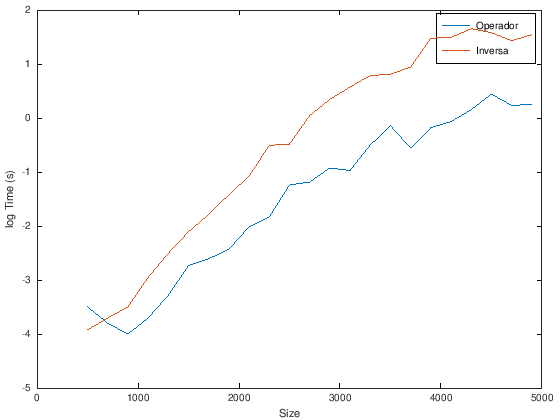

```matlab
plot([500:200:5000],log(t(:,1)),
    [500:200:5000],log(t(:,2)));
    legend(['Operador \';'Inversa']);
    xlabel('Size'); ylabel('log Time (s)');
```

#### Exemplo

Considere o sistema

$$\left\{\begin{array}{cll} x -y + 2z & = & 5 \\ -x + y + -z & = & -3 \\ 3x + 5y + 7z &= & -1 \\ \end{array}\right.$$

Observe que é possível representar o sistema de equações acima como uma igualdade entre dois vetore, $$Ax=b,$$ em que $$A= \left(\begin{array}{ccc}1 & -1 & 2 \\ -1 & 1 & -1 \\ 3 & 5 & 7 \end{array}\right), x=\left(\begin{array}{c} x \\ y \\ z\end{array}\right)\text{ e }b= \left(\begin{array}{c}5 \\ -3 \\ -1\end{array}\right).$$

Colocando em variáveis no Octave/Matlab, podemos encontrar a solução $x=\left(\begin{array}{r}-\frac{5}{4} \\ -\frac{9}{4} \\ 2\end{array}\right)$ como segue:

```matlab
format rat
A = [1 -1 2;
     -1 1 -1;
     3 5 7];
b=[5;-3;-1];
x = A\b
```

```
x =

       -5/4
       -9/4
          2
```

## Plotando gráficos

Para imprimirmos esse resultado, utilizaremos a função `plot` em sua sintaxe mais simples:

```
plot(D,f(D))
```

em que $D$ é o domínio do gráfico e f(D) é a imagem da função, no domínio especificado. Na próxima célula definiremos os conjuntos $D$, o conjunto $FD=\sin(D)$ e plotaremos esse resultado.

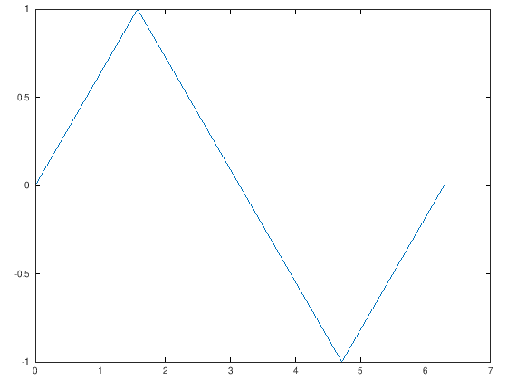

```matlab
D=[0;pi/2;pi;3*pi/2;2*pi];
FD=sin(D);
plot(D,FD)
```

Note que esse não é exatamente o gráfico do seno que conhecemos, mas sim uma aproximação. O comando `plot` liga cada ponto $(x, f (x))$, e como nesse caso só temos 5 pontos, o gráfico terá apenas 5 pontos.

Vamos usar o comando `linspace` para criar um vetor com uma quantidade grande o suficientede elementos. Por exemplo, se quisermos um vetor de 50 elementos:

```matlab
x = linspace(0, 2*pi, 50);
```

Isso fará com que $x$ seja o vetor que tem $0$ como primeiro, elemento, $2\pi$ como último elemento, e $48$ elementos entre eles. Por fim, criamos o vetor com o seno aplicado a cada elemento de x e o plotamos

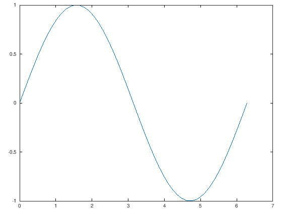

```matlab
y = sin(x);
plot(x, y);
```

O Octave/Matlab te dá algumas possibilidades de plot 2D. Com a função plot, você poderá plotar mais de um gráfico em uma única janela, ou plotar em subjanelas, adicionar título, legenda, alterar o formato do domínio e imagem, etc. Aqui vamos explorar algumas possibilidades. Fique livre em explorar outras possibilidades.

### Mult-line plots

Caso necessite plotar dois gráficos de um mesmo domínio em uma só janela, com a função `plot` é possível. Para isso, basta adicionar mais elementos na função, a ver

```
plot(D,I1,D,I2,...,D,In)
```

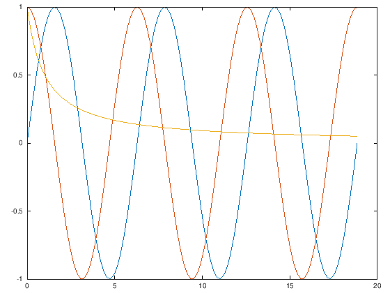

```matlab
x=linspace(0,6*pi,100);
plot(x,sin(x),x,cos(x),x,1./(1+x))
```

Você pode, ainda, utilizar a sintaxe

```
plot(D,F(D))
hold on
plot(D,G(D))
hold on
plot(D,H(D))
hold off
```

para plotar diversos gráficos em uma mesma janela.

### Subplots

A sintaxe para criar subplots, ou seja, multiplos plots em diferentes janelas, é

```
subplot(m,n,p)
```

em que $m$ é o número de linhas, $n$ é o número de colunas e $p$ é a posição em que o gráfico irá ocupar. Para ilustrar melhor, vamos observar a seguinte imagem (Fonte: http://matlab.izmiran.ru/help/techdoc/ref/subplot.html):

[figure not shown]

Observe que, o plot nomeado como `subplot 221` é o gráfico na posição $p=1$, de um conjunto de gráficos 4 gráficos, em uma "matriz de gráficos" $m\times n$, com $m=n=2$. Confuso? SIM :( Vamos para a prática.

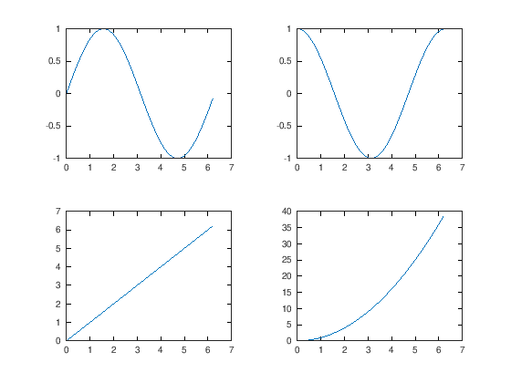

```matlab
x = [0:0.1:2*pi];
subplot(221); plot(x,sin(x));
subplot(222); plot(x,cos(x));
subplot(223); plot(x,x);
subplot(224); plot(x,x.^2);
```

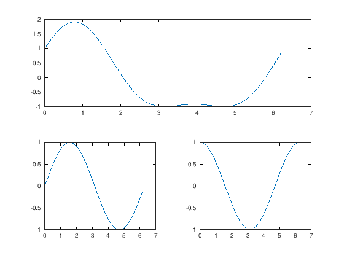

```matlab
x = [0:0.1:2*pi]';
subplot(223); plot(x,sin(x));
subplot(224); plot(x,cos(x));
subplot(2,2,[1 2]); plot(x,sin(x) + cos(x) + cos(x).*sin(x));
```

### Plot a partir de matrizes

Você pode armazenar todos os gráficos que queira imprimir em uma mesma janela em uma matriz e aplicar a função `plot` nela:

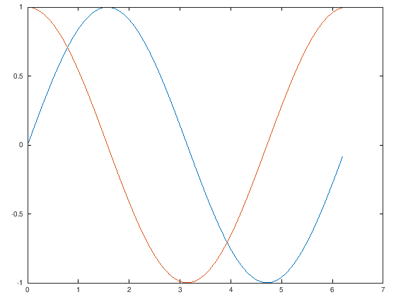

```matlab
x=[0:0.1:2*pi]';
A=[sin(x) sin(x+pi/2)];
plot(x,A)
```

### Design dos plots

É possível mudar o design dos gráficos. Você poderá alterar as cores das linhas e até o formato da linha (pontilhado, tracejado, etc). A sintaxe pode ser:

```
plot(D,F(D),'opcao 1','opcao 2', ... , 'opcao n',D, G(D), 'opcao n+1','opcao n+2',...)
```

em que $D$ é o domínio do seu gráfico, $F(D)/G(D)$ são as imagens, e $'opcao \ k'$ são as opções de design que você escolher.

Algumas das opções podem ser vistas nas tabelas a seguir:

#### Cores

| Nome | código | cor |
| --- | --- | --- |
| Vermelho | 'r' |  |
| Verde | 'g' |  |
| Azul | 'b' |  |
| Ciano | 'c' |  |
| Magenta | 'm' |  |
| Amarelo | 'y' |  |
| Preto | 'k' |  |
| Branco | 'w' |  |

É possível, ainda, utilizar a sintaxe

```
plot(D,FD,'Color',RGB_code)
```

para utilizar a cor que desejar. Por exemplo:

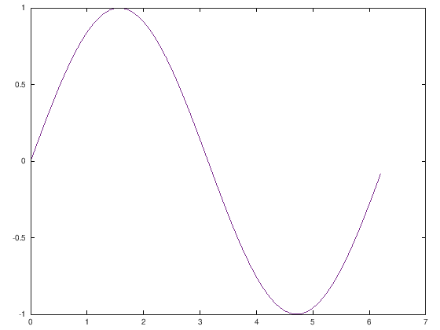

```matlab
plot(x,sin(x),'Color',[0.4940 0.1840 0.5560])
```

### Linestile e Marker

#### Linestile

| Descrição | Código | Resultado |
| --- | --- | --- |
| Linha sólida (padrão) | '$-$' |  |
| Tracejado | '$- -$' |  |
| Pontilhado | ':' |  |
| Traço e ponto | '$- .$' |  |

#### Mark

| Código | Descrição |
| --- | --- |
| `'o'` | Círculo |
| `'+'` | Sinal de + |
| `'*'` | Asterisco |
| `'.'` | Ponto |
| `'x'` | X |
| `'_'` | Linha horizontal |
| `'\|'` | Linha Vertical |
| `'square'` or `'s'` | Quadrado |
| `'diamond'` or `'d'` | Losango |
| `'^'` | Acento circunflexo |
| `'v'` | Letra V |
| `'>'` | Símbolo de maior |
| `'<'` | Símbolo de menor |
| `'pentagram'` or `'p'` | Pentagrama |
| `'hexagram'` or `'h'` | Hexagrama |

Vamos ver alguns exemplos:

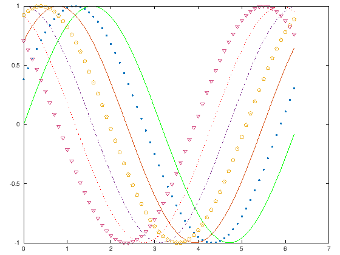

```matlab
plot(x,sin(x),'g');
hold on;
plot(x,sin(x+pi/8),'.');
hold on;
plot(x,sin(x+2*pi/8),'-');
hold on;
plot(x,sin(x+3*pi/8),'p');
hold on;
plot(x,sin(x+4*pi/8),'-.');
hold on;
plot(x,sin(x+5*pi/8),':','Color','r');
hold on;
plot(x,sin(x+6*pi/8),'<','Color',[214, 85, 135]./255);
hold off;
```

### Outros parâmetros do plot

A função plot tem alguns outros parâmetros que podem ser adicionados à janela do gráfico, como legenda, título, rótulo dos eixos, tamanho, etc. Vejamos alguns desses parâmetros:

```
plot(D,F(D),D,G(D), ... , D, Z(D));
title('...'); % Título do gráfico
legend(['...',...,'...']); % Legenda dos gráficos que compõe a janela do plot.
xlabel('...'); % Define o rótulo do eixo x
ylabel('...'); % Define o rótulo do eixo y
xlim([a b]); % Define o subdomínio do eixo x a ser exibido no gráfico
ylim([a b]); % Define o subdomínio do eixo y a ser exibido no gráfico
```

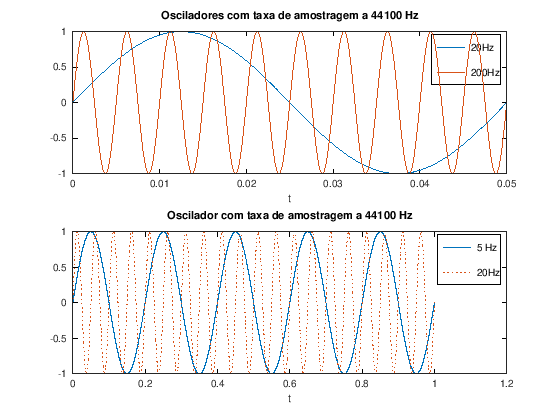

```matlab
t=[0:1/44100:1]';
y=sin(2*pi*20*t);
z=sin(2*pi*200*t);
subplot(211);
plot(t,y);
hold on;
plot(t,z);
hold off;
title('Osciladores com taxa de amostragem a 44100 Hz');
legend(['20Hz';'200Hz']);
xlim([0 0.05]);
xlabel('t');

% ----------------------------------------------------------------------

y=sin(2*pi*5*t);
z=sin(2*pi*20*t);
subplot(212);
plot(t,y);
hold on;
plot(t,z,':');
hold off;
title('Oscilador com taxa de amostragem a 44100 Hz');
legend(['5 Hz';'20Hz']);
xlim([0 1.2]);
xlabel('t');
```

## Cálculo no Octave

Neste módulo, vamos precisar de um pacote para Octave chamado "Symbolic". Nele, poderemos fazer cálculos simbólicos, isto é, utilizar `x` como variável. É possível que no Matlab já venha instalado. Caso esteja usando Octave, será necessário fazer algumas instalações antes.

### Instalação

1. Verifique sua instalação de Python (https://www.python.org/) e SymPy (https://www.sympy.org/en/index.html). Caso não os tenha instalados no seu computador, por favor, verifique como instalar eles corretamente. O SymPy necessário para que o Symbolic do Octave rode corretamente é a versão 1.5.1. Caso você instale uma versão posterior, será necessário fazer o downgrade.

`UBUNTU/macOS`

Verifique q versão do seu python instalado fazendo

```
python --version
```

Caso não tenha o Python3.9 instalado no seu computador faça

```
sudo apt update
sudo apt install python3.9
```

Instale o PIP:

```
curl https://bootstrap.pypa.io/get-pip.py -o get-pip.py
python3.9 get-pip.py
```

Instale o Sympy (v. 1.5.1)

```
pip3.9 install sympy==1.5.1
```

1. Abra o Octave e execute

   ```
   pkg install -forge symbolic
   pkg load symbolic
   ```

`WINDOWS`

- Download symbolic-win-py-bundle-2.7.0.zip em https://github.com/cbm755/octsympy/releases
- Abra o octave e execute

  ```
  pkg install symbolic-win-py-bundle-2.7.0.zip
  pkg load symbolic
  ```

```matlab
pkg install -forge symbolic
pkg load symbolic
```

```
For information about changes from previous versions of the symbolic package, run 'news symbolic'.
```

O objetivo da matemática simbólica, aqui, é para simularmos a continuidade de funções. Lembre-se que no computador, trabalhamos com matemática discreta. Assim, a definição de limite, derivada e integral, como conhecemos, não se aplica aqui. Por isso é necessário utilizar da simulação de continuidade para efetuarmos os cálculos dessas funções.

Ao instalar com sucesso o pacote de matemática simbólica em seu computador, utilizaremos uma função deste pacote chamada `syms`, para declarar a variável que iremos referenciar.

No seu Octave, digite:

```matlab
syms x;
```

```
Symbolic pkg v2.9.0: Python communication link active, SymPy v1.5.1.
```

Após definirmos nossa função simbólica, podemos definir nossas funções. Para definir a função $f(x)=\sqrt{\frac{1}{x^2+1}}$, fazemos

```matlab
fx = sqrt(1/(x^2+1))
```

```
fx = (sym)

       ________
      ╱   1
     ╱  ──────
    ╱    2
  ╲╱    x  + 1
```

### Limite

Para calcularmos o `Limite` na função $f(x)$ acima, utilizaremos a função `limit`, cuja sintaxe é

```
limit(fx,x,a)
```

em que `fx` é a função que queremos calcular o limite, `x` é a variável a se aplicar esse limite e `a` é o escalar tal que $x\to a$. Por exemplo:

```matlab
limit(fx,x,1)
```

```
ans = (sym)

  √2
  ──
  2
```

### Derivada

Para o cálculo da $n$-ésima derivada da função $f(x)$ utilizaremos a função `diff` cuja sintaxe é

```
diff(fx,n)
```

em que `fx` é a função que queremos calcular e `n` é o grau da derivada que queremos calcular. No octave, obtemos:

```matlab
disp('Primeira derivada de f(x)')
disp(diff(fx))
disp('Segunda derivada de f(x)')
disp(diff(fx,2))
disp('7-ésima derivada de f(x)')
disp(diff(fx,7))
```

```
Primeira derivada de f(x)
          ________
         ╱   1
  -x⋅   ╱  ──────
       ╱    2
     ╲╱    x  + 1
  ─────────────────
         2
        x  + 1
Segunda derivada de f(x)
  ⎛    2     ⎞      ________
  ⎜ 3⋅x      ⎟     ╱   1
  ⎜────── - 1⎟⋅   ╱  ──────
  ⎜ 2        ⎟   ╱    2
  ⎝x  + 1    ⎠ ╲╱    x  + 1
  ──────────────────────────
             2
            x  + 1
7-ésima derivada de f(x)
        ⎛         6           4         2     ⎞      ________
        ⎜    429⋅x       693⋅x     315⋅x      ⎟     ╱   1
  315⋅x⋅⎜- ───────── + ───────── - ────── + 35⎟⋅   ╱  ──────
        ⎜          3           2    2         ⎟   ╱    2
        ⎜  ⎛ 2    ⎞    ⎛ 2    ⎞    x  + 1     ⎟ ╲╱    x  + 1
        ⎝  ⎝x  + 1⎠    ⎝x  + 1⎠               ⎠
  ───────────────────────────────────────────────────────────
                                   4
                           ⎛ 2    ⎞
                           ⎝x  + 1⎠
```

É possível avaliar o valor das derivadas (e das funções) nos pontos desejados. Para isso, utilizaremos a função `subs`, cuja sintaxe é

```
x=k;
subs(fx)
```

em que `x` é a variável que queremos avaliar, `k` é o valor em que substituiremos o $x$ e `fx` é a função. Por exemplo:

````matlab
disp('------------'); disp('');
x=2;
disp('f(2)='); disp(subs(fx)); disp(''); disp('------------'); disp('');
disp('f`(2)='); disp(subs(diff(fx))); disp(''); disp('------------'); disp('');
disp('f```(2)='); disp(subs(diff(fx,3))); disp(''); disp('------------'); disp('');
````

````
------------

f(2)=
  √5
  ──
  5

------------

f`(2)=
  -2⋅√5
  ──────
    25

------------

f```(2)=
  -6⋅√5
  ──────
   125

------------
````

### Integrais

Para calcularmos `integrais indefinidas`, devemos usar a função `int`, cuja sintaxe é

```
int(fx)
```

em que `fx` é a função que queremos avaliar. No octave, a integral indefinida da função $$g(x)=\int \ln{x}-x^3 dx$$ fica

```matlab
syms x;
g=log(x)-x^3;
int(g)
```

```
ans = (sym)

     4
    x
  - ── + x⋅log(x) - x
    4
```

Para calcularmos `integrais definidas`, utilizaremos a mesma função anterior, adicionando os limites de integração na sintaxe. Ou seja, para calcular $$\int\limits_{a}^{b}f(x)dx,$$ utiliza-se a sintaxe

```
int(fx,a,b)
```

onde `fx` é a função que queremos avaliar, `a` é o limite inferior e `b` é o limite superior. No octave:

```matlab
int(g,1,2)
```

```
ans = (sym) -19/4 + 2⋅log(2)
```

### Gráficos das funções simbólicas

Muitas vezes, tem-se a necessidade de visualizarmos as funções que estamos trabalhando. Assim, para plotarmos os gráficos de funções simbólicas, utilizaremos a função `ezplot`, cuja sintaxe é

```
ezplot(fx,DOM)
```

em que `fx` é a função que queremos visualizar e DOM é um vetor linha de 2 variáveis $DOM=[xmin xmax]$, que definirá o domínio da função. No octave:

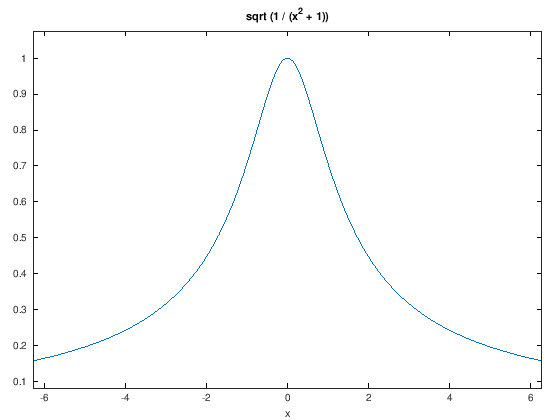

```matlab
ezplot(fx,[-2*pi 2*pi])
```

## Programação

Um algoritmo é uma sequência finita de ações executáveis, precisos e não ambíguos a fim de obter uma solução para um determinado problema. Já a linguagem de programação traduz um algoritmo (sequência de instruções/ações) da linguagem humana para a linguagem de máquina.

Uma maneira eficiente de projetar um algorítmo é por meio de um *pseudo código*. Por exemplo, se eu quero escrever um algoritmo que devolve o módulo de um número, em qualquer linguagem de programação, seu pseudo código pode ser escrito da seguinte forma:

```
Dado um número a
Se a >= 0, então
    modulo = a
Senão
    modulo=-a
retorna modulo
```

Em C++, por exemplo, o algorítmo acima poderia ser escrita como uma função, e ficaria assim:

```
double modulo(double x){
    double m;
    if (x >= 0){
        m = x;
    } else {
        m = -x;
    }
    return m;
}
```

Em Python, por exemplo, esse mesma função ficaria

```
def modulo(x):
    if x>=0:
        m = x
    else:
        m = -x
    return m
```

Cada linguagem de programação tem suas características. No Matlab/Octave, por exemplo, a mesma função acima ficaria:

```matlab
function m = modulo(x)
    if x >= 0
        m = x;
    else
        m = -x;
    end
end
m1 = modulo(-2)
m2 = modulo(-2332)
```

```
m1 = 2
m2 = 2332
```

Algumas observações importantes na hora de criarmos nossos algoritmos aqui no Octave/Matlab:

- Todo texto depois de `%` é considerado um comentário;
- O caractere `...` indica que o comando continua na próxima linha. Tal recurso permite deixar o texto mais organizado;
- Usa-se o ponto e vírgula `;` (lembra dele?) no final de uma linha de comando. Ele omite na janela de comandos as iterações que serão realizadas (mantém a janela de comando mais limpa e organizada);
- Pode-se colocar mais de um comando em uma linha, separando-os por ponto e vírgula;
- Os nomes das variáveis devem ser palavras únicas, sem inclusão de espaços e devem começar com uma letra, seguida de letras ou números, podendo conter até $19$ caracteres;
- Para a entrada de dados via teclado usa-se a função `input`;
- Para mostrar mensagens de texto na tela utiliza-se o comando `disp`.
- Você pode usar a função tic/toc para contar o tempo de execução do algoritmo. Por exemplo:

  ```
  tic;
  % algoritmo
  toc;
  ```

### Comando lógico-relacionais

| Operações lógicas | Descrição |
| --- | --- |
| $\sim$ | Negação |
| $\vert$ | ... ou ... |
| & | ... e ... |

**OBS**: Operações *curto-circuito*

- `expr1 && expr2` representa a operação lógica `... e ...` e aplica um comportamento de curto circuito no código. Isto é, $expr2$ não é avaliada se $expr1$ é `falso`.
- `expr1 || expr2` representa a operação lógica `... ou ...` e aplica um comportamento de curto circuito no código. Isto é, $expr2$ não é avaliada se $expr1$ for verdadeira.

| Operações relacionais | Descrição |
| --- | --- |
| $==$ | Igual a |
| $\sim =$ | Diferente |
| $<$ | menor do que |
| $>$ | maior do que |
| $<=$ | menor ou igual a ($\leq$) |
| $>=$ | maior ou igual a ($\geq$) |

O Octave/Matlab possui estruturas que permitem o controle do fluxo de execução de comandos e da ordem em que a computação é feita.

### Laço FOR

A estrutura `FOR` possibilita que um bloco de código seja repetido por um número de vezes fixo e predefinido. Sua sintaxe é:

```
for variável = início:passo:fim
    % comandos
end
```

#### Exemplo

1) Faça um algoritmo usando laço FOR que retorne a soma dos números de $1$ a $N$, em que $N$ é dado pelo usuário.

```matlab
N = input('Digite um número natural: ');

disp(' ')
disp('Método 1 - Laço FOR')
disp(' ')
soma = 0;
tic;
for n = 1:N
    soma = soma + n;
end
disp(['A soma de 1 até ' num2str(N) ' é ' num2str(soma)]);
toc;
```

```
Digite um número natural:2343

Método 1 - Laço FOR

A soma de 1 até 2343 é 2745996
Elapsed time is 0.015285 seconds.
```

**OBS**: Laços for nem sempre são a melhor forma de construir um algoritmo, em Matlab/Octave. Vou escrever o mesmo algorimo acima usando vetores e funções nativas. Vamos comparar os tempos.

```matlab
disp(' ')
disp('Método 2 - vetores e funções nativas')
disp(' ')

tic;
t = [1:N];
soma2 = sum(t);
disp(['A soma de 1 até ' num2str(N) ' é ' num2str(soma)]);
toc;
```

```
Método 2 - vetores e funções nativas

A soma de 1 até 2343 é 2745996
Elapsed time is 0.0112772 seconds.
```

### Laço WHILE

A estrutura while é utilizada quando é necessário repetir certo comando de código várias vezes, enquanto uma determinada condição é satisfeita. Geralmente, usa-se while quando não se sabe ao certo a quantidade de passos a serem dados pelo algoritmo. Sintaxe:

```
while expressão
    comandos
end
```

#### Exemplo

1) Encontre o menor número $n\in\mathbb{N}\cup\{0\}$ tal que $\frac{1}{2^n} < 10^{-12}$ .

```matlab
x=1;
n=0;
while x>1e-12
    n = n+1;
    x = x/2;
end
disp(['Quando n = ' num2str(n) ', a sequência 1/(2^n) chegou a ' num2str(x)]);
```

```
Quando n = 40, a sequência 1/(2^n) chegou a 9.0949e-13
```

2) Encontre o menor número natural tal que $\sqrt[n]{n} < 1 + 10^{-5}$.

```matlab
format long
n=2;
while n^(1/n) > 1 + 1e-5
    n = n + 1;
end

disp(['A sequência n^(1/n) vale ' num2str(n^(1/n)) ' quando n = ' num2str(n)])
```

```
A sequência n^(1/n) vale 1 quando n = 1416368
```

3) Encontre o menor número, maior ou igual a um $N$ fornecido pelo usuário que é múltiplo de $7$.

```matlab
N = input('Digite um número natural: ');

while rem(N,7) ~= 0
    N = N+1;
end

disp([num2str(N) ' é múltiplo de 7.'])
```

```
Digite um número natural:2343
2345 é múltiplo de 7.
```

### If, Elseif e Else

A estrutura `if` é usada para executar um bloco de comandos apenas se uma determinada condição for satisfeita. Sintaxe:

```
if expressão1
    % comandos 1
elseif expressão2
    % comandos 2
elseif expressão3
    % comandos 3
else
    % comandos 4
end
```

#### Exemplo

1) Faça um programa que diga se a pessoa é adulta, adolescente, criança ou idosa, com base na idade fornecida. Use o comando While para fazer o usuário digitar uma idade maior do que zero.

```matlab
idade_correta = false;
while ~idade_correta
    idade = input('Informe sua idade: ');
    if idade > 0
        idade_correta = true;
    end
end

if idade < 12
    disp('Você é uma criança.')
elseif idade >= 12 & idade < 18
    disp('Você é um adolescente.')
elseif idade >= 18 & idade < 65
    disp('Você é um adulto.')
else
    disp('Você é um idoso')
end

if idade > 150
    disp(' ')
    disp(' ')
    disp(' ')
    disp('... Chico Xavier, é você?')
end
```

```
Informe sua idade:231
Você é um idoso



... Chico Xavier, é você?
```

### Switch, case, otherwise

O switch executa uma ação dentre várias opções, dependendo de um parâmetro passado inicialmente, onde cada escolha é um caso. Sintaxe:

```
switch variável_de_teste
case{caso1}
    % comandos1
case{caso2}
    % comandos2
case{caso3}
    % comandos3
otherwise
    % comandos
end
```

#### Exemplo

1) Construa um programa onde o usuário digita dois números e indica se irá somá-los, multiplicá-los ou subtraí-los.

```matlab
n = input('Digite um número: '); m = input('Digite um número: ');
operacao = input('Digite: 1 para somá-los; 2 para subtraí-los; 3 para multiplicá-los. Opção: ');

switch operacao
case{1}
    oper='+';
    x=n+m;
case{2}
    oper='-';
    x=n-m;
case{3}
    oper='*';
    x=m*n;
otherwise
    x=NaN;
    disp('Essa não é uma operação válida')
end
if x ~= NaN
    disp([num2str(n) oper num2str(m) '=' num2str(x)])
end
```

```
Digite um número:12
Digite um número:12
Digite: 1 para somá-los; 2 para subtraí-los; 3 para multiplicá-los. Opção:1
12+12=24
```

### Funções

Muitas vezes não será necessário criarmos uma nova função, pois o Octave/MATLAB já nos traz uma grande biblioteca de funções pré-definidas. Por exemplo: se quisermos calcular o fatorial de um número $n$, não é necessário criar uma nova função para isso, basta usarmos a função

```
factorial(n).
```

Algumas funções pré-definidas no Octave/MATLAB:

| Função | Descrição |
| --- | --- |
| factorial($n$) | Retorna o fatorial de $n$ |
| $\sin(n)$ | Retorna o seno de $n$ |
| $sqrt(n)$ | Retorna a raíz quadrada de um número $n$ |
| gcd($n$,$m$) | Retorna o maior divisor comum entre $n$ e $m$ |
| rem($n$,$m$) | Retorna o resto de divisao de $n$ por $m$ |

Muitas vezes queremos criar funções que ainda não estão na biblioteca virtual do Octave/MATLAB. Para isso temos o comando $function$, que obedece a seguinte sintaxe:

```
function[saida] = nomedafuncao(entrada)
    % Comentário da função, que aparecerá quando fizer '>>> help nomedafuncao'
    <comandos>
end
```

#### Exemplo

Dados dois números, queremos uma função que nos retorne a soma e o produto dos dois. Vamos utilizar o function:

```matlab
function [s,p] = somaprod(a,b)
    % Função que retorna a soma e o produto de dois números dados.
    s = a + b;
    p = a*b;
end
```

Agora basta salvar o arquivo como `somaprod.m`. Para executar a função, basta digitarmos no Octave/MatLab que o propgrama irá retornar os vaores de soma e produto. Vale lembrar que, quando uma função retorna 2 ou mais valores, é possível solicitar apenas um deles, como veremos na célula abaixo.

```matlab
disp('Imprimindo os dois valores:')
[a,b]=somaprod(11,12)
disp(' ')
disp('Imprimindo o primeiro valor')
c = somaprod(11,12)

disp(' ')
disp('Imprimindo o segundo valor')
[~,d]=somaprod(11,12)

disp(' ')
disp('Pedindo help da função')
help somaprod
```

```
Imprimindo os dois valores:
a =  23
b =  132

Imprimindo o primeiro valor
c =  23

Imprimindo o segundo valor
d =  132

Pedindo help da função
'somaprod' is a command-line function

 Função que retorna a soma e o produto de dois números dados.


Additional help for built-in functions and operators is
available in the online version of the manual.  Use the command
'doc <topic>' to search the manual index.

Help and information about Octave is also available on the WWW
at http://www.octave.org and via the help@octave.org
mailing list.
```